# Bayesian Computation for Approximate Inference

- Sampling
  - Random Number Generation
  - Probability Integral Transform
  - PIT Example with code
- Rejection Sampling
  - Intuition
  - Coded Example
- Importance Sampling
  - Uniform Grid
  - Sampling with Importance
  - Importance Sampling and normalization constants
- Markov Chain Monte Carlo
  - Markov Chains fundamentals
  - Metropolis Algorithm
  - Metropolis Algorithm with code
  - Metropolis-Hastings
- Variational Inference
  - Variational inference vs MCMC
  - KL divergence and Evidence Lower Bound (ELBO)
  - Local Variational Methods
    - Overview
    - Maximization Problem
    - Minimization Problem
    - Local Methods for Non-Convex functions
    - Local Methods with Gaussian bounds
- Laplace Approximation
- Laplace Approximation and Logistic Regression
  - Proof that class posterior has sigmoid form
  - Assuming Gaussian class conditionals
  - Log Posterior of Bayesian logistic regression
  - Laplace approximation of Posterior
- Data Analysis

$$ \DeclareMathOperator*{\argmax}{arg\,max} \DeclareMathOperator*{\argmin}{arg\,min} \newcommand{\def}{\overset{\text{def}}{:=}} \newcommand{\lop}{\mathcal{L}} \newcommand{\vect}[1]{\boldsymbol{\mathbf{#1}}} \newcommand{\norm}[1]{||#1||} \newcommand{\vx}{\vect{x}} \newcommand{\vb}{\vect{b}} \newcommand{\vy}{\vect{y}} \newcommand{\vz}{\vect{z}} \newcommand{\ve}{\vect{e}} \newcommand{\vc}{\vect{c}} \newcommand{\vf}{\vect{f}} \newcommand{\vY}{\vect{Y}} \newcommand{\vX}{\vect{X}} \newcommand{\vw}{\vect{w}} \newcommand{\vm}{\vect{m}} \newcommand{\vt}{\vect{t}} \newcommand{\linearpredictor}{\vx_i^T\vbeta} \newcommand{\vmu}{\vect{\mu}} \newcommand{\vnu}{\vect{\nu}} \newcommand{\veta}{\vect{\eta}} \newcommand{\vbeta}{\vect{\beta}} \newcommand{\vepsilon}{\vect{\epsilon}} \newcommand{\Pbb}{\mathbb{P}} \newcommand{\Ebb}{\mathbb{E}} \newcommand{\Rbb}{\mathbb{R}} \newcommand{\sample}{\vz^{(l)}} \newcommand{\MYhref}[3][blue]{\href{#2}{\color{#1}{#3}}}% \newcommand{\sol}[1]{\vx^{(#1)}} \newcommand{\qtext}[1]{\quad\quad \text{#1}} \newcommand{\vtheta}{\vect{\theta}} \newcommand{\bi}[1]{\textbf{\textit{#1}}} \newcommand{\iid}{\overset{\text{i.i.d.}}{\sim}} \newcommand{\uniform}{\mathcal{U}(0, 1)} \newcommand{\qimplies}{\quad\Longrightarrow\quad} \newcommand{\tp}{\tilde{p}} \newcommand{\const}{\mathcal{Z}} \newcommand{\tq}{\tilde{q}} \newcommand{\tr}{\tilde{r}} \newcommand{\like}{\mathcal{L}} \newcommand{\kl}[2]{\text{KL}(#1\,\,||\,\,#2)} \newcommand{\logit}[1]{\log\left(\frac{#1}{1-#1}\right)} \newcommand{\elbo}[1]{\text{elbo}(#1)} \newcommand{\eval}{\biggr\rvert} \newcommand{\normal}{\mathcal{N}} \newcommand{\class}{\mathcal{C}} \newcommand{\vSigma}{\vect{\Sigma}} $$

## Sampling

In order to sample complicated distributions, we need to be able to sample a uniform distribution. In other words, we need to be able to generate random numbers within an interval.

#### Uniform (pseudo-) Random Number Generator

A uniform pseudo-random number generator is an algorithm that starting from an initial value $u_0$ uses a transformation $D$ to produce a sequence $(u_i) = (D^i(u_0))$ of values in the interval $[0, 1]$. These values will *reproduce* the behavior of i.i.d. $V_1, \ldots, V_n \sim \mathcal{U}(0, 1)$ when compared through some tests. The most commonly used tests are:

- Kolmogorov-Smirnov test to test differences in location and shape of the empirical CDFs of two samples.
- ARMA(p, q) to find degree of correlation between $V_i$ and $V_{i-1}, \ldots, V_{i-k}$.

#### Probability Integral Transform Theorem

Once we can generate uniform random numbers we can from any distribution thanks to the PIT theorem which says that *any random variable is a transformation of a uniform random variable*. Possible formulations are:

- $Y\sim \mathcal{U}(0, 1) \quad \Longrightarrow \quad F^{-1}(Y)$ has cdf $F$
- $X$ has cdf $F \quad \Longrightarrow \quad Y = F(X) \sim \mathcal{U}(0, 1)$

#### PIT Theorem Example

Suppose we had $X\sim \text{Exp}(1)$ with CDF $F(x) = 1-e^{-x}$. The inverse CDF would be $F^{-1}(y) = -\log(1 -y)$. By the PIT theorem we should have that if $Y\sim \mathcal{U}(0, 1)$, then $X\equiv -\log(1 - Y)$ is distributed as $X\sim \text{Exp}(1)$.

We can see that this is indeed correct in the following example. Let us define some functions first:

```python
# Import whatever is needed
import numpy as np
import matplotlib.pyplot as plt
import pandas as pd

# Define Exponential PDF
def pdf_exp(x, theta=1):
    return theta*np.e**(-theta*x)

# Define Exponential CDF
def cdf_exp(x, theta=1):
    return 1 - np.e**(-theta*x)

# Define Exponential Inverse CDF
def cdf_exp_inverse(u, theta=1):
    return -(1/theta)*np.log(1 - u)
```

Now we generate some uniform samples and feed them into the inverse CDF function

```python
u = np.random.rand(10000)
exp = cdf_exp_inverse(u)  # These should now be sample of the exponential(1) distribution
```

Finally, we can plot these samples

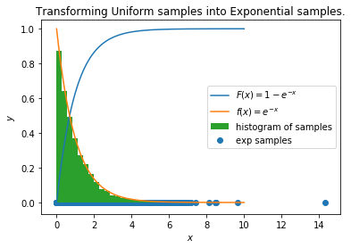

```python
x = np.linspace(0, 10, 1000)
fig, ax = plt.subplots()
ax.plot(x, cdf_exp(x), label=r'$F(x)=1-e^{-x}$')
ax.plot(x, pdf_exp(x), label=r'$f(x)=e^{-x}$')
ax.scatter(exp, np.zeros_like(exp), label='exp samples')
ax.hist(exp, bins=50, density=True, label='histogram of samples')
ax.set_xlabel(r"$x$")
ax.set_ylabel(r"$y$")
ax.set_title("Transforming Uniform samples into Exponential samples.")
ax.legend()
plt.show()
```

Similarly, we can feed the exponential samples into $F$ and obtain uniformly distributed samples.

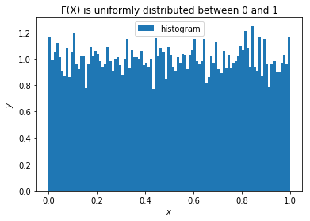

```python
uniform = cdf_exp(exp)
plt.hist(uniform, bins=100, density=True, label='histogram')
plt.title("F(X) is uniformly distributed between 0 and 1")
plt.legend()
plt.xlabel(r"$x$")
plt.ylabel(r"$y$")
plt.show()
```

## Rejection Sampling

Used to sample from *complex distributions*. We assume:

- Difficult to *sample* from $p(\vz)$
- Easy to *compute* $p(\vz)$ for any $\vz$, up to a normalizing constant. That is we can calculate $\tilde{p}(\vz)$ but we don't know the normalizing constant $\const_p$ $$p(\vz) = \frac{\tilde{p}(\vz)}{\const_p}$$

We choose a **proposal distribution** $q(\vz)$ that is easy to sample from and such that we can rescale it to be always above $\tilde{p}(\vz)$, the unnormalized target distribution. That is, we can find $k$ such that for all $\vz$: $$\tilde{p}(\vz) \leq k q(\vz)$$ We call $kq(\vz)$ the **comparison function**. Notice that by construction it is always above $\tilde{p}(\vz)$ and it therefore cannot be a PDF (because it doesn't integrate to $1$). Rejection sampling then can be outlined as follows:

- Draw sample from proposal distribution $\sample \sim q(\vz)$
- Draw a *uniform* sample underneath the comparison function $\vect{u}_l \sim U([0, kq(\sample)])$
- If uniform sample is above the unnormalized target distribution $\vect{u}_l > \tilde{p}(\sample)$ then reject the sample $\sample$. Otherwise, accept.

#### Intuition

We are basically generating uniform samples under *graph* of the comparison function $$(\sample, \vect{u}_l)\sim U(\{(z, u)\, : \, 0\leq u \leq kq(z)\})$$ and we are accepting them if they are also under the graph of $\tilde{p}(\vz)$. Therefore, *accepted* samples are distributed proportionally to the target distribution $\sample \sim \tilde{p}(\vz)$. Since this proportionality constant $\const_p$ is constant for all samples, we are *effectively* sampling from $p(\vz)$.

The probability of acceptance is $$\Pbb(\text{accept}) = \frac{\text{area under } \tilde{p}(\vz)}{\text{area under } kq(\vz)} = \frac{\const_p}{k}$$ So to minimize useless computation, we want to find $k$ as small as possible.

#### Coded Example

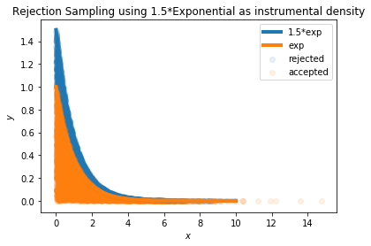

```python
# Plot target and instrumental densities
x = np.linspace(0, 10, 100)
k = 1.5
plt.plot(x, pdf_exp(x)*k, label='{}*exp'.format(k), lw=4)
plt.plot(x, pdf_exp(x), label='exp', lw=4)

# Generate exponential samples
u = np.random.rand(10000)
exp = cdf_exp_inverse(u)

# Sample from the instrumental
samples_instr = exp * k
# Sample uniformly from 0 to instrumental value
unif = np.random.uniform(0, pdf_exp(samples_instr) * k)
pdf_values = pdf_exp(samples_instr)
# Color-code samples based on accepted/rejected
mask = pdf_values >= unif
plt.scatter(samples_instr[~mask], unif[~mask],
            label='rejected', alpha=0.1)
plt.scatter(samples_instr[mask], unif[mask],
            label='accepted', alpha=0.1)
plt.title("Rejection Sampling using {}*Exponential as "
          "instrumental density".format(k))
plt.xlabel(r"$x$")
plt.ylabel(r"$y$")
plt.legend()
plt.show()
```

## Importance Sampling

Used to estimate *properties* or *summaries* of a probability distribution, such as the expectation. These properties are estimated by using samples drawn from a different probability distribution. Importance sampling is used when:

- Sampling from target distribution $p(\vz)$ is *difficult*.
- It is easy to *compute* $p(\vz)$ for every $\vz$.
- Want to lower the variance of our estimate.

#### Uniform Grid

Since drawing samples $\sample$ from $p(\vz)$ is difficult, but evaluating $p(\vz)$ is easy for every $\vz$, one could discretize $\vz$ with a uniform grid and evaluate:

$$\Ebb_p[f] \approx \sum_{l=1}^L p(\sample)f(\sample)\quad\quad\quad\text{where } \sample \text{ are gridpoints}$$

The two main drawbacks are that

- the number of gridpoints **grows exponentially** with the dimension of $\vz$.
- Often $p(\vz)$ will have most of its mass in a small region of the $\vz$ space, therefore having a *uniform* grid will be inefficient because only few samples will contribute.

#### Sampling with Importance

Choose a **proposal distribution** $q(\vz)$ that is easy to sample from and that it is "biased" towards here $p(\vz)$ has more mass. In other words, it encourages values that are more *important* for the approximation. Drawing samples $\{\sample \}$ from $q(\vz)$ we can calculate our summaries as:

$$\Ebb_p[f] = \int f(\vz)p(\vz)d\vz = \int f(\vz) \frac{p(\vz)}{q(\vz)}q(\vz)d\vz= \Ebb_q\left[f(\vz)\frac{p(\vz)}{q(\vz)}\right]\approx \frac{1}{L}\sum_{l=1}^L\frac{p(\sample)}{q(\sample)}f(\sample)\quad\quad\quad \text{where } \sample\sim q(\vz)$$

We call $r_l = \frac{p(\sample)}{q(\sample)}$ **importance weights** and they correct the bias introduced by sampling from the wrong distribution.

#### Importance Sampling with unknown normalization constants

Often we don't know normalization constants of our target and proposal distributions, i.e. $\const_p$ and $\const_q$, but we are still able to easily compute $\tilde{p}(\vz)$ and $\tilde{q}(\vz)$ for every $\vz$. In this case we do:

$$\Ebb_p[f] = \int f(\vz)p(\vz)d\vz = \int f(\vz)\frac{p(\vz)}{q(\vz)}q(\vz)d\vz = \frac{\const_q}{\const_p}\int f(\vz)\frac{\tp(\vz)}{\tq(\vz)}q(\vz)d\vz = \frac{\const_q}{\const_p}\Ebb_q\left[f(\vz)\frac{\tp(\vz)}{\tq(\vz)}\right]\approx \frac{\const_q}{\const_p} \frac{1}{L}\sum_{l=1}^L \tr_l f(\sample)$$

We can't evaluate the result above just yet because the normalizing constants are unknown. However we can find their ratio as follows:

$$\frac{\const_p}{\const_q} = \frac{1}{\const_q}\int \tp(\vz)d\vz = \frac{1}{\const_q}\int \frac{\tp(\vz)}{\tq(\vz)}\tq(\vz)d\vz = \int \frac{\tp(\vz)}{\tq(\vz)}q(\vz)d\vz = \Ebb_q\left[\frac{\tp(\vz)}{\tq(\vz)}\right]\approx \frac{1}{L} \sum_{l=1}^L \tr_l$$

Combining these results we get:

$$\Ebb_p[f]\approx \left(L \frac{1}{\sum_{l=1}^L \tr_l}\right) \frac{1}{L}\sum_{l=1}^L \tr_l f(\sample) = \sum_{l=1}^L\frac{\tr_l}{\sum_{m=1}^M \tr_m}f(\sample) = \sum_{l=1}^L w_l f(\sample)$$

## Markov Chain Monte Carlo

#### Markov Chains fundamentals

> An MCMC sampler is an _irreducible_ and _aperiodic_ Markov Chain that has the target distribution as the _invariant distribution_.

A discrete-time **Markov Chain** is a sequence of random variables $\vz^{(1)}, \ldots, \vz^{(m)}$ taking values in a *finite* **state space** $\mathcal{S}$ and having the Markov Property: the probability of moving to the next state only depends on the current state, that is:

$$p(\vz^{(m+1)}\mid \vz^{(1)}, \ldots, \vz^{(m)}) = p(\vz^{(m+1)}\mid \vz^{(m)})$$

In order to fully specify the Markov Chain we only need to specify:

- Probability distribution for initial variable $p(\vz^{(0)})$ (which is usually a vector of probabilities summing up to $1$)
- Conditional probability distributions for subsequent variables. These are called **transition probabilities** and are usually denoted as $T_m(\vz^{(m)}, \vz^{(m+1)}) := p(\vz^{(m+1)}\mid \vz^{(m)})$

When the transition probabilities are the same for all $m$, we say that the Markov Chain is **homogeneous**. In this case we have a *fixed* $d\times d$ transition matrix, where $d = |\mathcal{S}|$ is the number of possible states and whose elements are $T_{ij} = p(\vz^{(m+1)} = i \mid \vz^{(m)}=j)$. Given the initial probability distribution $p(\vz^{(0)})$ we can write the probability $p(\vz^{(t)})$ of ending up in each state after $t$ steps as: $$p(\vz^{(t)}) = T^t p(\vz^{(0)})$$ When it exists, the limiting distribution $p^{*}(\vz) = \lim_{t\to\infty}p(\vz^{(t)})$ is said to be a **stationary distribution** of the Markov Chain. The stationary distribution is invariant with respect to the transition probability matrix, meanining that it remains unchanged as we progress through the chain.

A *sufficient* condition for $p^*(\vz)$ to be stationary is that it has to satisfy the **detailed balance** property: $$p^*(\vz)T(\vz, \vz') = p^*(\vz')T(\vz', \vz) \quad \text{i.e.} \quad p^*(\vz)p(\vz'\mid \vz) = p^*(\vz')p(\vz\mid\vz')$$ In this case the Markov Chain is said to be **reversible**.

In order for MCMC to work we need:

- Markov Chain such that target distribution is the invariant distribution.
- Markov Chain is **ergodic**, that is $\lim_{m\to\infty} p(\vz^{(m)}) = p^*(\vz)$ *irrespective* of the choice of the initial distribution $p(\vz^{(0)})$. In this case we call the invariance distribution, the **equilibrium distribution** and it is unique.

Basically *existence* of the stationary distribution is given by the detailed balance property, while *uniqueness* is given by ergodicity.

#### Metropolis Algorithm

Assume that the transition / proposal probability is **symmetric**, that is $q(\vz_A\mid \vz_B) = q(\vz_B\mid \vz_A)$ for all $\vz_A$ and $\vz_B$. We define the probability that a *candidate* sample $\vz^{*}$ is accepted as $$A(\vz^{*}\mid \vz^{m}) := \min\left(1, \, \frac{\tilde{p}(\vz^{*})}{\tilde{p}(\vz^{(m)})}\right)$$

1. Choose arbitrary initial sample $\vz^{(0)}$ and a *symmetric* transition probability distribution $p(\vz^{(m+1)} \mid \vz^{(m)})$.
2. Sample from $p(\vz^{*} \mid \vz^{(m)})$ to generate candidate sample $\vz^{*}$.
3. Draw $u\sim \uniform$ and calculate acceptance probability $$A(\vz^{*}, \vz^{(m)}) := \min\left(1, \, \frac{\tilde{p}(\vz^{*})}{\tilde{p}(\vz^{(m)})}\right)$$
4. If $A(\vz^{*}, \vz^{(m)}) > u$, then accept the candidate and set $\vz^{(m+1)}= \vz^{*}$. Otherwise set $\vz^{(m+1)}= \vz^{(m)}$ and $m := m+1$, and sample again from $p(\vz^{*}\mid \vz^{(m)})$

Notice that the proposal distribution is usually a Gaussian centered at $\vz^{(m)}$. In this case sequence is a Random Walk. Also, notice that until a candidate sample is not rejected, we will keep creating multiple copies of the current sample. In practical implementations these copies would be discarded though and an integer counting their occurency would be stored.

It is important to note that **successive samples are highly correlated**. To obtain an independent sample one has to discard most of the sequence and only keep every $M^{\text{th}}$ sample, for $M$ large.

#### Metropolis in Python

The following code shows an example of when a candidate would be accepted with probability $1$:

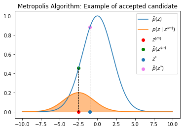

```python
from scipy.stats import norm

# Plot between -10 and 10 with .001 steps.
x_axis = np.arange(-10, 10, 0.001)
# Mean = 0, SD = 3.
plt.plot(x_axis, norm.pdf(x_axis,0,2)*5, label=r'$\tilde{p}(z)$')
plt.plot(x_axis, norm.pdf(x_axis, -2.5, 2), label=r'$p(z\mid z^{(m)})$')
plt.fill_between(x_axis, norm.pdf(x_axis, -2.5, 2), color='#ff7f0e', alpha=0.5)
z_m = -2.5
z_star = -1
plt.scatter([z_m], [0], color='red', label=r'$z^{(m)}$')
plt.plot((z_m, z_m), (0, norm.pdf(z_m, 0, 2)*5), linestyle='--', color='k', lw=1)
plt.scatter([z_m], [norm.pdf(z_m, 0, 2)*5], color='green', label=r'$\tilde{p}(z^{(m)}$')
plt.scatter([z_star], [0], label=r'$z^{*}$')
plt.plot((z_star, z_star), (0, norm.pdf(z_star, 0, 2)*5), linestyle='--', color='k', lw=1)
plt.scatter([z_star], [norm.pdf(z_star, 0, 2)*5], color='violet', label=r'$\tilde{p}(z^{*})$')
plt.legend()
plt.title("Metropolis Algorithm: Example of accepted candidate")
plt.show()
```

In the picture above $p(\vz^{*}) > p(\vz^{(m)})$ so our candidate will be accepted with probability $1$.

The following is an implementation of the Metropolis algorithm using a Gaussian distribution as proposal distribution:

```python
from scipy.stats import norm, t, expon

def Metropolis(p, z0=None, n_samples=100, burn_in=0, thinning=1, tune=False):
    """
    Metropolis Random-Walk algorithm.

    Parameters
    -----------
    p : function
        Target distribution that we want to sample from.
    z0 : float
         Initial sample. If None, a U(0, 1) sample is taken.
    n_samples : int
                Number of final samples in the output after burn in and thinning.
    burn_in : int
              Number of initial samples that are disgarded from the final output.
    thinning : int
               At the end of sampling we select every "thinning" sample to reproduce independence.
    tune : bool
           If True, we run Metropolis() with 10% of n_samples, then use 2.38**2 * np.var(tune_samples)
           as the value of the standard deviation of our proposal normal distribution.

    Returns
    -------
    np.array
            List of burned-in and thinned samples with length n_samples
    """
    z = z0 if z0 is not None else np.random.uniform()
    pz = p(z)
    # calculate total number of calculations
    tot = burn_in + (n_samples - 1)*thinning + 1
    # stores all the samples
    sample_list = np.zeros(tot)
    # Generate uniform random numbers outside the loop
    u = np.random.uniform(size=tot)
    # Can tune proposal standard deviation according to ESS, see
    # Weak convergence and optimal scaling of random walk Metropolis algorithms (1997).
    # A. Gelman, W. R. Gilks, and G. O. Roberts.
    # or https://stackoverflow.com/questions/54763690/speed-up-metropolis-hastings-in-python
    if tune:
        tune_samples = Metropolis(p, z0, int(0.1*n_samples), burn_in, thinning, tune=False)
        scale = 2.38**2 * np.var(tune_samples)
    else:
        scale = 1
    # If z is N(0, 1), then sigma*Z + mu is N(mu, sigma^2)
    normal_shift = norm.rvs(loc=0, scale=scale, size=tot)  # scale is standard deviation

    for i in range(tot):
        # Sample a candidate from Normal(mu, sigma)
        cand = z + normal_shift[i]
        # Acceptance probability
        try:
            p_cand = p(cand)
            prob = min(1, p_cand / pz)
        except (OverflowError, ValueError) as error:
            continue

        if prob > u[i]:  # accept
            z = cand
            pz = p_cand  # to save computations

        sample_list[i] = z

    # Finally want to take every Mth sample in order to achieve independence
    return sample_list[burn_in::thinning]
```

```python
# Get tuned and untuned exponential samples
untuned_exponential = Metropolis(p=expon.pdf, n_samples=1000, burn_in=500, thinning=10)
tuned_exponential = Metropolis(p=expon.pdf, n_samples=1000, burn_in=500, thinning=10, tune=True)
# Get tuned and untuned t samples
untuned_t = Metropolis(p=t(df=10).pdf, n_samples=1000, burn_in=500, thinning=10)
tuned_t = Metropolis(p=t(df=10).pdf, n_samples=1000, burn_in=500, thinning=10, tune=True)
```

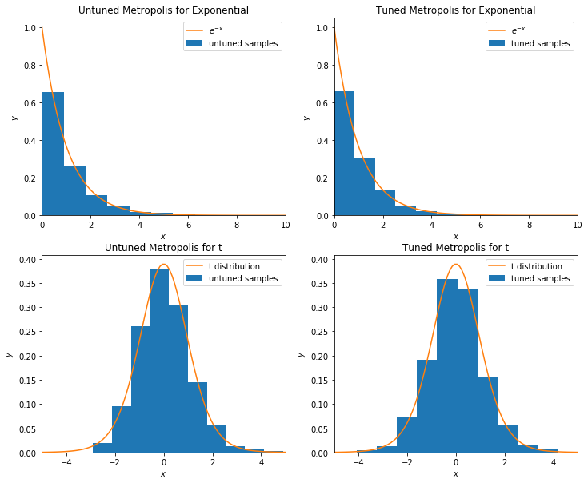

```python
x = np.linspace(0, 10, 100)
xt = np.linspace(-5, 5, 100)
fig, axes = plt.subplots(nrows=2, ncols=2, figsize=(12, 10))
# untuned exponential
axes[0, 0].hist(untuned_exponential, density=True, label='untuned samples')
axes[0, 0].plot(x, expon().pdf(x), label=r'$e^{-x}$')
axes[0, 0].set_xlim(0, 10)
axes[0, 0].legend()
axes[0, 0].set_title("Untuned Metropolis for Exponential")
axes[0, 0].set_xlabel(r'$x$')
axes[0, 0].set_ylabel(r'$y$')
# tuned exponential
axes[0, 1].hist(tuned_exponential, density=True, label='tuned samples')
axes[0, 1].plot(x, expon().pdf(x), label=r'$e^{-x}$')
axes[0, 1].set_xlim(0, 10)
axes[0, 1].legend()
axes[0, 1].set_title("Tuned Metropolis for Exponential")
axes[0, 1].set_xlabel(r'$x$')
axes[0, 1].set_ylabel(r'$y$')
# untuned t
axes[1, 0].hist(untuned_t, density=True, label='untuned samples')
axes[1, 0].plot(xt, t(df=10).pdf(xt), label=r't distribution')
axes[1, 0].set_xlim(-5, 5)
axes[1, 0].legend()
axes[1, 0].set_title("Untuned Metropolis for t")
axes[1, 0].set_xlabel(r'$x$')
axes[1, 0].set_ylabel(r'$y$')
# tuned t
axes[1, 1].hist(tuned_t, density=True, label='tuned samples')
axes[1, 1].plot(xt, t(df=10).pdf(xt), label=r't distribution')
axes[1, 1].set_xlim(-5, 5)
axes[1, 1].legend()
axes[1, 1].set_title("Tuned Metropolis for t")
axes[1, 1].set_xlabel(r'$x$')
axes[1, 1].set_ylabel(r'$y$')
plt.show()
```

#### Metropolis-Hastings

Transition distribution $T(\vz^*, \vz)$ will be made of two components:

- Transition kernel / proposal distribution $q(\vz^* \mid \vz^{(m)})$: probability of proposing $\vz^*$ given $\vz^{(m)}$
- Acceptance probability $A(\vz^*, \vz)$ of accepting candidate $\vz^*$ given $\vz^{(m)}$ defined as: $$A(\vz^*, \vz) = \min\left(1, \, \frac{p(\vz^*)q(\vz\mid \vz^*)}{p(\vz)q(\vz^*\mid \vz)}\right)$$

Therefore $T(\vz^*, \vz) = q(\vz^*\mid \vz)A(\vz^*, \vz)$. Notice that when the proposal distribution is symmetric, then the Metropolis-Hastings reduces to the Metropolis algorithm. The following is the MH algorithm:

1. Choose initial sample $\vz^{(0)}$
2. Draw $\vz^*\sim q(\vz^*\mid \vz)$ to generate a candidate and evaluate acceptance probability $$A(\vz^*, \vz) = \min\left(1, \, \frac{p(\vz^*)q(\vz\mid \vz^*)}{p(\vz)q(\vz^*\mid \vz)}\right)$$
3. Draw uniformly distributed sample $u\sim \uniform$
4. If $A(\vz^*, \vz) > u$ accept the candidate and set $\vz^{(m+1)} = \vz^*$. Otherwise, reject and set $\vz^{(m+1)} = \vz^{(m)}$

## Variational Inference

Approximates complex posterior densities faster than MCMC and it is easier to scale. Uses optimization instead of sampling. The general idea is:

- Define a *family* of densities $\mathcal{D}$ over the parameters.
- Try to find density in $\mathcal{D}$ closer to the exact posterior. Usually our "metric" is the KL-divergence: $$q^*(\vtheta) = \argmin_{q(\vtheta)\in\mathcal{D}} \kl{q(\vtheta)}{p(\vtheta\mid \vx)}$$

#### Comparing MCMC and Variational Inference

- MCMC more computationally intensive than VI, but produces asymptotically exact samples from the target distribution.
- VI can use advances in optimization like stochastic optimization, but underestimates variance of target distribution.

In general Variational Inference should be chosen instead of MCMC when we are working with **large datasets** and **speed** is more important than precision.

#### An overview of KL divergence and ELBO

KL divergence is *asymmetric* $\kl{p}{q}\neq \kl{q}{p}$, *non negative* $\kl{p}{q}\geq 0$ and it is minimized when $p=q$. We usually can't evaluate the KL divergence, because it depends on the log-evidence, which is what we are trying to evaluate in the first place: $$\kl{q(\vtheta)}{p(\vtheta\mid \vx)} := \Ebb_q[\log(q(\vtheta) - \log(p(\vtheta\mid \vx))]=\ldots = \Ebb_q[\log(q(\vtheta))] - \Ebb_q[\log(p(\vx, \vtheta))] + \log(p(\vx))$$ To fix this, we define the **Evidence Lower Bound (ELBO)** as follows, which allows us to remove the log-evidence: $$\elbo{q} = -\kl{q(\vtheta)}{p(\vtheta\mid \vx)} + \log(p(\vx))$$ ELBO is called like this because it can be shown that it provides a lower bound for the log-evidence, that is $$\log(p(\vx)) \geq \elbo{q} \qquad \forall q(\vtheta)\in \mathcal{D}$$ Notice that maximizing the evidence lower bound is equivalent to minimizing the KL divergence. What is the meaning of maximizing the evidence lower bound? We can see this by re-writing the elbo as follows: $$\elbo{q} = \underbrace{\Ebb_q[\log(p(\vx\mid \vtheta))]}_{\text{expected log-likelihood}} - \underbrace{\kl{q(\vtheta)}{p(\vtheta)}}_{\text{KL of $q(\vtheta)$ and prior}}$$

Maximizing elbo means that the first term is large, that is we encourage densities over $\vtheta$ with mass explaining the data. Similarly, maximizing elbo means that the second term is small, that is we encourage densities close to the prior in KL divergence.

#### Local Variational Methods

##### Overview

Variational Methods described above are *global* because they seek to approximate the full posterior over all random variables. *Local* approaches, instead, seek a bound on functions such as a conditional distribution that is part of a much larger probabilistic model, usually specified by a directed graph. Complex functions will play an important role.

##### Approximation of exponential function via maximization

A simple example is to try and approximate the convex function $f(x) = e^{-x}$ by a linear function of $x$. The linear function will be a lower bound on $f(x)$ if it corresponds to a tangent line. Take the Taylor Expansion of $f(x)$ at $x=\xi$ and truncate it at the first order, in order to obtain a tangent line. Call this tangent line $y(x)$: $$y(x) = f(\xi) + f'(\xi)(x - \xi) = \exp(-\xi) - \exp(-\xi)(x - \xi)$$ Because this truncation neglets higher order terms, we must have $y(x)\leq f(x)$, with equality when $x=\xi$. We define $\eta:= -\exp(-\xi)$ so we write the tangent line as $$y(x) = \exp(-\xi) - \exp(-\xi)x + \exp(-\xi)\xi = \eta x - \eta -\exp(-\xi)(\ln(\exp(-\xi)) = \eta x - \eta + \eta \ln(-\eta) =: y(x, \eta)$$ Different values of $\eta$ correspond to different tangent lines. Each of these tangent lines will be a lower bound on $f(x)$, that is $f(x)\geq y(x, \eta)$ however these tangents will be exactly equal to the function at the point in which they are tangent. Therefore we can approximate the function $f(x)$ using a simpler linear function $y(x, \eta)$ which depends on a **variational parameter** $\eta$: $$f(x) = \max_{\eta}\{\eta x - \eta +\eta \ln(-\eta)\}$$

##### Approximation of exponential function via minimization

Imagine that we take the linear function $\eta x$. This is a lower bound of $f(x)$ because for fixed $\xi$ we have that $\eta x = -\exp(-\xi)x$ is just a linear function in $x$, and:

- If $x \geq 0$, then $e^{-x}>0$ but $\eta x := -x\exp(-\xi) \leq 0$ so that $f(x) > \eta x$ for all $x\geq 0$.
- If $x < 0$, then call $\tilde{x}=-x$ and we have $f(x) = e^{-x} = e^{\tilde{x}} > \tilde{x}\exp(-\xi)$ for $\exp(-\xi)$ sufficiently small.

Therefore $f(x) > \eta x$ for all $x$. Notice that the line $\eta x$ is not necessarily tangent, but rather will have some discrepancy as in the following example.

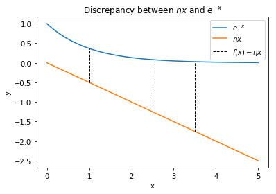

```python
# The following example shows how eta x could have a discrepancy with e^{-x}
x = np.linspace(0, 5, 100)
plt.plot(x, np.e**(-x), label=r'$e^{-x}$')
plt.plot(x, -0.5*x, label=r'$\eta x$')
x_disc1 = 1
x_disc2 = 2.5
x_disc3 = 3.5
plt.plot((x_disc1, x_disc1), (-0.5*x_disc1, np.e**(-x_disc1)), linestyle='--', lw=1, color='k', label=r'$f(x)-\eta x$')
plt.plot((x_disc2, x_disc2), (-0.5*x_disc2, np.e**(-x_disc2)), linestyle='--', lw=1, color='k')
plt.plot((x_disc3, x_disc3), (-0.5*x_disc3, np.e**(-x_disc3)), linestyle='--', lw=1, color='k')
plt.title(r'Discrepancy between $\eta x$ and $e^{-x}$')
plt.xlabel('x')
plt.ylabel('y')
plt.legend()
plt.show()
```

The $\eta x$ line plotted above has been plotted with slope $\eta=-0.5$. By the mean value theorem we know that there exists a value $x$ where the tangent of $f(x)$ will have exactly this slope. Such tangent can be found by minimizing the discrepancy with respect to $x$. Minimizing the discrepancy with respect to $x$ is equivalent to solving the **dual problem**.

We can denote the tangent line to $f(x)$ at the point $x$ as $\eta x - g(\eta)$ where $-g(\eta)$ is the intercept, and therefore $g(\eta)$ is the *negative* intercept. To determine this intercet we need to move $\eta x$ vertically until we match $f(x)$ for the first time. Looking at the graph above, we see that the discrepancy between $\eta x$ and $f(x)$ varies with $x$, but it is smallest where the tangent of $f(x)$ at $x$ has exactly slope $\eta$.

In other words, we can find $g(\eta)$ by moving $\eta x$ by the smallest vertical distance between $\eta x$ and $f(x)$, that is $$-g(\eta) = \min_x\{f(x) - \eta x\} \quad \Longrightarrow \quad g(\eta) = -\min_x\{f(x)-\eta x\} = \max_x\{\eta x -f(x)\}$$

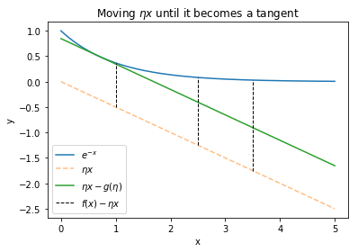

```python
# The following example shows the movement of eta x to match the tangent line. Notice x = ln(2)
x = np.linspace(0, 5, 1000)
plt.plot(x, np.e**(-x), label=r'$e^{-x}$')
plt.plot(x, -0.5*x, label=r'$\eta x$', linestyle='--', alpha=0.5)
g_eta = 0.5 + 0.5*np.log(2)
plt.plot(x, -0.5*x + g_eta, label=r'$\eta x-g(\eta)$')
x_disc1 = 1
x_disc2 = 2.5
x_disc3 = 3.5
plt.plot((x_disc1, x_disc1), (-0.5*x_disc1, np.e**(-x_disc1)), linestyle='--', lw=1, color='k', label=r'$f(x)-\eta x$')
plt.plot((x_disc2, x_disc2), (-0.5*x_disc2, np.e**(-x_disc2)), linestyle='--', lw=1, color='k')
plt.plot((x_disc3, x_disc3), (-0.5*x_disc3, np.e**(-x_disc3)), linestyle='--', lw=1, color='k')
plt.title(r'Moving $\eta x$ until it becomes a tangent')
plt.xlabel('x')
plt.ylabel('y')
plt.legend()
plt.show()
```

##### Applying local variational methods to non-convex functions

For *concave* functions we simply replace 'max' by 'min' so that we have $$f(x) = \min_\eta \{\eta x - g(\eta)\}$$ $$g(\eta) = \min_x \{\eta x - f(x)\}$$

What to do when function is not convex nor concave? Consider the logistic sigmoid function, which is neither convex nor concave $$\sigma(x) = \frac{1}{1 + e^{-x}}$$

We notice that the logarithm of this function $f(x):=\ln(\sigma(x)) = -\ln(1 + e^{-x})$ is concave so we can apply the second of the two formulas above. We minimize $\eta x + \ln(1 + e^{-x})$ with respect to $x$ by taking the derivative and setting it to zero: $$\eta - \frac{e^{-x}}{1 + e^{-x}} = 0 \qimplies e^{-x} = \frac{\eta}{1-\eta}\qimplies x = \ln(1 - \eta) - \ln(\eta)$$

Therefore $g(\eta) = -\eta\ln{\eta} - (1-\eta)\ln(1-\eta) =: H_{\text{bin}}(\eta)$. Considering the first of the two equations given at the beginning of this section we see that by definition of minimum $$\ln(\sigma(x)) = f(x) = \min_x\{\eta x - g(\eta)\} \leq \eta x - g(\eta)$$ So that we've found an upper bound for the log sigmoid. However, initially we wanted a bound for the logistic on its own. To achieve that, we simply transform back to our original function by taking the exponential $$\sigma(x)\leq \exp(\eta x - g(\eta))$$

##### Local Variational Methods with Gaussian upper bound

Rewrite the log sigmoid as follows: $$\ln(\sigma(x)) = -\ln(1 + e^{-x}) = -\ln\left(e^{-\frac{x}{2}}\left(e^{\frac{x}{2}} + e^{-\frac{x}{2}}\right)\right) = \frac{x}{2} - \ln\left(e^{\frac{x}{2}} + e^{-\frac{x}{2}}\right)$$

We notice that $f(x) = - \ln\left(e^{\frac{x}{2}} + e^{-\frac{x}{2}}\right)$ is a convex function of the variable $x^2$. As we have seen, we can find a lower bound on $f(x)$ that is **linear** in $x^2$ and whose conjugate function is $$g(\eta) = \max_x\left\{\eta x^2 - f\left(\sqrt{x^2}\right)\right\}$$

Using the fact that $\tanh(x) := \frac{e^x - e^{-x}}{e^{x} + e^{-x}}$ we can then differentiate $\eta x^2 - f\left(\sqrt{x^2}\right)$ with respect to $x^2$ and set it equal to zero (remember to use the chain rule!) to get $$\eta - \frac{dx}{dx^2}\frac{d}{dx}f(x) = 0 \qimplies \eta + \frac{1}{4x}\tanh\left(\frac{x}{2}\right) = 0$$

Now recall that $\eta$ is a particular value of the tangent line at the point $x$. We now denote the value of $x$ at which the line with slope $\eta$ is tangent to $f(x)$ by $\xi$ we can write $$\eta = -\frac{1}{4\xi}\tanh\left(\frac{\xi}{2}\right) = -\frac{1}{2\xi}\left[\sigma(\xi) - \frac{1}{2}\right] = -\lambda(\xi)$$ where we have used the fact that the hyperbolic tangent is just a rescaled sigmoid, i.e. $\tanh(x) = 2\sigma(2x) - 1$. Also, we have then defined $\lambda = -\eta$ just for notation purposes.

Now recall that our conjugate function was $$g(\eta) = \max_{x^2}\left\{\mu x^2 + \ln\left(e^{\frac{x}{2}} + e^{-\frac{x}{2}}\right)\right\}$$ We can replace $\eta$ by $-\lambda(\xi)$ and therefore set $x=\xi$. While before the variational parameter was $\eta$, now we consider $\xi$ to be such parameter. We therefore obtain $$g(\lambda(\xi)) = -\lambda(\xi)\xi^2 + \ln\left(e^{\frac{\xi}{2}} + e^{-\frac{\xi}{2}}\right)$$

Now recall that usually we found the bound on $f(x)$ as follows $$f(x) = \max_\eta\{\eta x -g(\eta)\} \geq \eta x - g(\eta) \qimplies f(x)\geq \eta x - g(\eta)$$

In our case we therefore have $$f(x) \geq -\lambda(\xi)x^2 - g(\lambda(\xi)) = -\lambda(\xi)x^2 +\lambda(\xi)\xi^2 - \ln\left(e^{\frac{\xi}{2}} + e^{-\frac{\xi}{2}}\right)$$

Now recall that $\ln(\sigma(x)) = \frac{x}{2} - \ln\left(e^{\frac{x}{2}} + e^{-\frac{x}{2}}\right)$. Therefore we add $\frac{x}{2}$ to both sides and add $\frac{\xi}{2} - \frac{\xi}{2} = 0$ to the right hand side: $$\ln(\sigma(x)) \geq -\lambda(\xi)(x^2 - \xi^2) -\frac{\xi}{2} + \frac{\xi}{2} - \ln\left(e^{\frac{\xi}{2}} + e^{-\frac{\xi}{2}}\right) = \frac{(x - \xi)}{2}-\lambda(\xi)(x^2 - \xi^2) +\ln(\sigma(\xi))$$

Moving $\ln(\sigma(\xi))$ and using standard logarithm properties we have $$\ln\left(\frac{\sigma(x)}{\sigma(\xi)}\right) \geq \frac{(x - \xi)}{2}-\lambda(\xi)(x^2 - \xi^2)$$

Exponentiating both sides and rearranging we get $$\sigma(x) \geq \sigma(\xi)\exp\left\{\frac{(x - \xi)}{2}-\lambda(\xi)(x^2 - \xi^2)\right\}$$

Which is a Gaussian lower bound on the sigmoid.

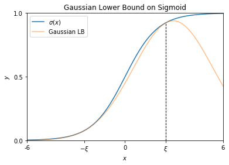

```python
# Code for Gaussian Lower Bound on sigmoid
# Define sigmoid function, lambda(xi) function and the gaussian lower bound
def sigmoid(x):
    return 1 / (1 + np.exp(-x))

def lamb(xi):
    return (1 / (2*xi))*(sigmoid(xi) - 0.5)

def gaussian_lb(x, xi):
    return sigmoid(xi)*np.exp((x-xi)/2 - lamb(xi)*(x**2 - xi**2))

# Choose a value for xi. This will indicate the x value where Gaussian will be tangent to sigmoid
xi = 2.5
# Choose axes limits
xlim_left = -6
xlim_right = 6
ylim_up = 1
ylim_down = 0

# Plot sigmoid and gaussian between x=-6 and x=6
x = np.linspace(-6, 6, 100)
plt.plot(x, sigmoid(x), label=r'$\sigma(x)$')
plt.plot(x, gaussian_lb(x, xi), label='Gaussian LB', alpha = 0.5)
# Plot xi and a helper line showing that Gaussian LB is tangent to sigmoid at x=xi
plt.plot((xi, xi), (0, sigmoid(xi)), linestyle='--', color='k', lw=1)
# improve appearance
plt.xlim(xlim_left, xlim_right)
plt.ylim(ylim_down, ylim_up)
plt.xlabel(r'$x$')
plt.ylabel(r'$y$')
plt.xticks([xlim_left, -xi, 0, xi, xlim_right], [xlim_left, r'$-\xi$', 0, r'$\xi$', xlim_right])
plt.yticks([ylim_down, 0.5, ylim_up])
plt.title("Gaussian Lower Bound on Sigmoid")
plt.legend()
plt.show()
```

## Laplace Approximation

The goal of Laplace Approximation is to approximate a pdf with a Gaussian centered at the mode of the pdf. Suppose that we want to approximate the following distribution $$p(\vz) = \frac{f(\vz)}{\const}$$ where $\vz$ si $M$-dimensional and $\const$ is the unknown normalizing constant. The mode is the maximum of the pdf and therefore $\vz_0$ is the mode of $f(\vz)$ if $\nabla f(\vz)\rvert_{\vz=\vz_0}$ and if the Hessian $\nabla^2 f(\vz)\rvert_{\vz=\vz_0}$ is negative definite. To simplify calculations instead of considering $f(\vz)$, we will consider $\ln f(\vz)$ which will be easier to work with because the natural logarithm of a Gaussian is a quadratic term. Also, notice that if $vz_0$ is the maximum of $f(\vz)$ then it is also the maximum of $\ln f(\vz)$ because logarithm is monotonically increasing.

We Taylor Expand $\ln f(\vz)$ to find a quadratic approximation, and then take the exponential of this, so that we effectively obtain a Gaussian approximation: $$\ln f(\vz) \approx \ln f(\vz_0) +\nabla \ln f(\vz)^T\eval_{\vz=\vz_0}(\vz - \vz_0) + \frac{1}{2!}(\vz-\vz_0)^T\nabla^2 \ln f(\vz) \eval_{\vz=\vz_0}(\vz-\vz_0)$$

Now we take the exponential on both sides and use the fact that $\vz_0$ is a stationary point, so that $\nabla \ln f(\vz)\eval_{\vz=\vz_0} = 0$ to obtain $$ \begin{align} f(\vz) &\approx \exp\left\{\ln f(\vz_0) +\nabla \ln f(\vz)^T\eval_{\vz=\vz_0}(\vz - \vz_0) + \frac{1}{2!}(\vz-\vz_0)^T\nabla^2 \ln f(\vz) \eval_{\vz=\vz_0}(\vz-\vz_0)\right\}\\ &= f(\vz_0)\exp\left\{\frac{1}{2}(\vz-\vz_0)^T\nabla^2 \ln f(\vz) \eval_{\vz=\vz_0}(\vz-\vz_0)\right\} \end{align} $$

Recall that a multivariate normal distribution with mean $\vmu$ and with $D\times D $ covariance matrix $\vect{\Sigma}$ can be written as $$\normal(\vx\mid \vmu, \vect{\Sigma}) = \frac{1}{(2\pi)^{\frac{D}{2}}}\frac{1}{\det\left(\vect{\Sigma}\right)^{\frac{1}{2}}}\exp\left\{-\frac{1}{2}(\vx -\vmu)^T \vect{\Sigma}^{-1}(\vx - \vmu)\right\}$$

Therefore our Gaussian approximation can be found by setting $D=M$ and $-\nabla^2 \ln f(\vz)\eval_{\vz=\vz_0} = \vect{\Sigma}^{-1}$ $$q(\vz) = \frac{\det\left(-\nabla^2 \ln f(\vz)\eval_{\vz=\vz_0}\right)^{\frac{1}{2}}}{(2\pi)^{\frac{M}{2}}} \exp\left\{\frac{1}{2}(\vz - \vz_0)^T\nabla^2 \ln f(\vz)\eval_{\vz=\vz_0} (\vz - \vz_0)\right\} = \frac{\det(A)^{\frac{1}{2}}}{(2\pi)^{\frac{M}{2}}}\exp\left\{-\frac{1}{2}(\vz - \vz_0)^T A (\vz - \vz_0)\right\} = \normal(\vz \mid \vz_0, A^{-1})$$

Where $A = -\nabla^2 \ln f(\vz)\eval_{\vz=\vz_0}$. Drawbacks of Laplace approximation are:

- Works only for real variables
- Based only on behavior of $p(\vz)$ at a single point $\vz_0$

## Laplace Approximation and Logistic Regression

#### Class Posterior probability has a logistic form

Goal: Given an input vector $\vx$ want to *classify* it into one of $2$ discrete classes $\mathcal{C}_1$ and $\mathcal{C}_2$. The target variable $t$ is *binary*: $$ \begin{equation} t = \begin{cases} 0 & \class_2\\ 1 & \class_1 \end{cases} \end{equation} $$

We can show that $p(\class_1\mid \vx)$ has a logistic form using Bayes formula: $$ \begin{align} p(\class_1\mid \vx) &= \frac{p(\vx\mid \class_1)p(\class_1)}{p(\vx\mid \class_1)p(\class_1) + p(\vx\mid \class_2)p(\class_2)} && \text{Bayes Theorem}\\ &= \frac{1}{1 + \frac{p(\vx\mid \class_2)p(\class_2)}{p(\vx\mid \class_1)p(\class_1)}} && \text{dividing by numerator}\\ &= \frac{1}{1 + \exp\left(\ln\left(\frac{p(\vx\mid \class_2)p(\class_2)}{p(\vx\mid \class_1)p(\class_1)}\right)\right)} \\ &= \frac{1}{1 + \exp\left(-\ln\left(\frac{p(\vx\mid \class_1)p(\class_1)}{p(\vx\mid \class_2)p(\class_2)}\right)\right)}\\ &= \frac{1}{1 + \exp(-a)} && \text{where } a:= \ln\left(\frac{p(\vx\mid \class_1)p(\class_1)}{p(\vx\mid \class_2)p(\class_2)}\right)\\ &= \sigma(a) \end{align} $$

#### Assumption that class-conditional densities are Gaussian

Assume that the class-conditional densities, $p(\vx\mid \class_1)$ and $p(\vx\mid \class_2)$, are Gaussian with common variance matrix $\vSigma$, that is: $$p(\vx\mid \class_k) = \normal(\vx\mid \vmu_k, \vect{\Sigma}) = \frac{1}{(2\pi)^{\frac{D}{2}}}\frac{1}{|\vect{\Sigma}|^{\frac{1}{2}}}\exp\left\{-\frac{1}{2}(\vx - \vmu_k)^T \vect{\Sigma}^{-1}(\vx-\vmu_k)\right\} \quad\quad \text{for } k=1, 2$$

Then we can find the form of our $a(\vx)$ by plugging this into its expression: $$ \begin{align} a(\vx) &= \ln\left(\frac{p(\vx\mid \class_1)p(\class_1)}{p(\vx\mid \class_2)p(\class_2)}\right) \\ &= \ln(p(\vx\mid \class_1)) - \ln(p(\vx\mid \class_2)) + \ln\left(\frac{p(\class_1)}{p(\class_2)}\right)\\ &= -\frac{1}{2}(\vx - \vmu_1)^T \vect{\Sigma}^{-1}(\vx-\vmu_1) + \frac{1}{2}(\vx - \vmu_2)^T \vect{\Sigma}^{-1}(\vx-\vmu_2) + \ln\left(\frac{p(\class_1)}{p(\class_2)}\right)\\ &= \vmu_1^T\vSigma^{-1}\vx - \vmu_2^T\vSigma^{-1}\vx - \frac{1}{2}\vmu_1\vSigma^{-1}\vmu_1 + \frac{1}{2}\vmu_2\vSigma^{-1}\vmu_2 + \ln\left(\frac{p(\class_1)}{p(\class_2)}\right) && \text{expanding the products}\\ &= \left(\vSigma^{-1}(\vmu_1-\vmu_2)\right)^T\vx - \frac{1}{2}\vmu_1\vSigma^{-1}\vmu_1 + \frac{1}{2}\vmu_2\vSigma^{-1}\vmu_2 + \ln\left(\frac{p(\class_1)}{p(\class_2)}\right) && \text{as } \vSigma^{-1} \text{ is symmetric}\\ &= \vect{w}^T\vx + w_0 \end{align} $$

where $\vect{w} := \vSigma^{-1}(\vmu_1-\vmu_2)$ and $w_0 := - \frac{1}{2}\vmu_1\vSigma^{-1}\vmu_1 + \frac{1}{2}\vmu_2\vSigma^{-1}\vmu_2 + \ln\left(\frac{p(\class_1)}{p(\class_2)}\right)$.

Therefore assuming Gaussian class-conditional probabilities leads to posterior probabilities that are sigmoids transformations of a linear function of the input $\vx$ $$p(\class_1\mid \vx) = \sigma(a(\vx)) = \sigma(\vw^T\vx + w_0)$$ Notice that in general we denote $y(\vx) = p(\class_1\mid \vx)$.

#### Log Posterior over the parameters

Again assume we have a dataset $\{\vx_n, t_n\}$. We can consider $t_n$ as beign $n$ independent Bernoulli trials. Notice $$\Pbb[T_n = 1] = p(\class_1 \mid \vx_n)$$ Therefore we can write down the log-likelihood as $$\ln(p(\vect{t} \mid \vw)) = \ln\left(\prod_{n=1}^N \Pbb[T_n = 1]^{t_n}(1 - \Pbb[T_n = 1])^{1-t_n}\right) = \sum_{n=1}^N t_n\ln(p(\class_1 \mid \vx_n)) + (1-t_n)\ln(p(\class_2 \mid \vx_n))$$

Using the notation $y_n = y(\vx_n) = p(\class_1\mid \vx_n)$ we can rewrite it as $$\ln(p(\vect{t}\mid \vw)) = \sum_{n=1}^N t_n\ln(y_n) + (1-t_n)\ln(1 - y_n)$$

We can find the posterior distribution for the parameters $\vw$ by recalling $p(\vw\mid \vect{t})\propto p(\vw)p(\vect{t}\mid \vw)$. Now since Laplace approximation works by fitting a Gaussian at the mode, we choose the prior distribution to be a Gaussian as well with fixed hyperparameters $\vect{m}_0$ and $\vect{S}_0$: $$p(\vw) = \normal(\vw\mid \vm_0, \vect{S}_0)$$

We therefore have $$ \begin{align} \ln(p(\vw\mid \vt)) &= \ln(p(\vw)) + \ln(p(\vt\mid \vw))\\ &= -\frac{1}{2}(\vw-\vm_0)^T\vect{S}_0^{-1}(\vw-\vm_0) + \sum_{n=1}^N t_n\ln(y_n) + (1-t_n)\ln(1 - y_n) + \text{ const } \end{align}$$

#### Applying Laplace Approximation to the posterior

Recall that Laplace approximation uses a normal distribution $\normal(\vw\mid \vw_{\text{MAP}}, A^{-1})$ where $\vw_{\text{MAP}}$ is the maximum of the posterior distribution, and $A:= -\nabla^2 \ln (\vw \mid \vt)\eval_{\vw=\vw_{\text{MAP}}}$

Let's start by computing the gradient with respect to $\vw$ of the first term in the log likelihood: $$ \begin{align} \nabla_{\vw}\ln(p(\vw)) &= \left(-\frac{1}{2}(\vw-\vm_0)^T\vect{S}_0^{-1}(\vw-\vm_0)\right) \\ &= -\frac{1}{2}\nabla_{\vw}\left(\vw^T\vect{S}_0^{-1}\vw - \vw^T\vect{S}_0^{-1}\vm_0 - \vm_0^T\vect{S}_0^{-1}\vw + \vm_0^T\vect{S}_0^{-1}\vm_0\right)\\ &= -\frac{1}{2}\left(2\vw^T\vect{S}_0^{-1} - \vect{S}_0^{-1}\vm_0 - \vect{S}_0^{-1}\vm_0\right) && \text{derivative of quadratic form and $\vect{S}_0^{-1}$ is symmetric} \end{align} $$ Therefore taking the gradient with respect to $\vw$ once again yields $$\nabla^2_{\vw}\ln(p(\vw)) = -\vect{S}_0^{-1} \qimplies -\nabla^2_{\vw}\ln(p(\vw)) = \vect{S}_0^{-1}$$ Now consider the second term in the log likelihood. First of all, notice that if we have a sigmoid function $\sigma(\vz)$ its derivative with respect to its argument can be shown to be $\frac{d \sigma(\vz)}{d\vz} = \sigma(\vz)(1 - \sigma(\vz))$. In our case we therefore have: $$\nabla_{\vw} y_n = \nabla_{\vw} \sigma(\vw^T \vx_n) = \sigma(\vw^T\vx_n)(1 - \sigma(\vw^T\vx_n))\vx_n = y_n(1- y_n)\vx_n$$

Using linearity of differentiation and standard differentiation results we have $$ \begin{align} \nabla_{\vw} \ln(p(\vt\mid \vw)) &= \sum_{n=1}^N \nabla_{\vw}\left(t_n\ln(y_n) + (1-t_n)\ln(1 - y_n)\right)\\ &= \sum_{n=1}^N \frac{t_n}{y_n}y_n(1- y_n)\vx_n + \frac{1-t_n}{1-y_n}(-y_n(1- y_n)\vx_n)\\ &= \sum_{n=1}^N t_n (1 - y_n)\vx_n - (1-t_n)y_n\vx_n\\ &= \sum_{n=1}^N t_n \vx_n - y_n\vx_n \end{align} $$

Taking a second gradient with respect to $\vw$ we obtain $$\nabla_{\vw}^2 \ln(p(\vt\mid \vw)) = -\sum_{n=1}^N y_n(1-y_n)\vx_n\vx_n^T \qimplies -\nabla_{\vw}^2 \ln(p(\vt\mid \vw)) = \sum_{n=1}^N y_n(1-y_n)\vx_n\vx_n^T$$ So that we obtain $$A:=- \nabla_{\vw}^2 \ln(p(\vt\mid \vw)) = \vect{S}_0^{-1} + \sum_{n=1}^N y_n(1-y_n)\vx_n\vx_n^T$$

The Laplace approximation is therefore given by $$q(\vw) = \normal(\vw\mid \vw_{\text{MAP}}, A^{-1})$$

# Data Analysis

```python
import pandas as pd
path = "D:\\Users\\Mauro\\Documents\\Main\\University\\MATHS\\PROJECT\\variational_inference\\material _from _forster\\BeetleMortality.csv"
data = pd.read_csv(path, index_col=0)
data.columns = ['Dose', 'NumberKilled', 'NumberExposed']
data['CenteredDose'] = data.Dose.values - data.Dose.mean()
data['CumulativeN'] = data.NumberExposed.cumsum()
data
```

|  | Dose | NumberKilled | NumberExposed | CenteredDose | CumulativeN |
| --- | --- | --- | --- | --- | --- |
| 1 | 1.6907 | 6 | 59 | -0.102725 | 59 |
| 2 | 1.7242 | 13 | 60 | -0.069225 | 119 |
| 3 | 1.7552 | 18 | 62 | -0.038225 | 181 |
| 4 | 1.7842 | 28 | 56 | -0.009225 | 237 |
| 5 | 1.8113 | 52 | 63 | 0.017875 | 300 |
| 6 | 1.8369 | 53 | 59 | 0.043475 | 359 |
| 7 | 1.8610 | 61 | 62 | 0.067575 | 421 |
| 8 | 1.8839 | 60 | 60 | 0.090475 | 481 |

```python
# Now recreate dataset with "fake" Bernoulli observations. Recall y_i = 1 means death
newrows = np.zeros((data.NumberExposed.sum(), 2))
for index, row in data.iterrows():
    obs = np.zeros(int(row.NumberExposed), dtype=int)
    obs[:int(row.NumberKilled)] = 1
    np.random.shuffle(obs)
    obs = obs.reshape(-1, 1)
    doses = np.repeat(row.Dose, len(obs)).reshape(-1, 1)
    obs = np.hstack((doses, obs))
    from_index = int(row.CumulativeN - row.NumberExposed)
    to_index = int(row.CumulativeN)
    newrows[from_index:to_index] = obs
# Save it as a dataframe
newrows = pd.DataFrame(newrows, columns=['x', 'y'])
# Notice that if you wanted to check that these calculations are correct use: newrows.groupby('x').sum()
newrows.head()
```

|  | x | y |
| --- | --- | --- |
| 0 | 1.6907 | 0.0 |
| 1 | 1.6907 | 0.0 |
| 2 | 1.6907 | 0.0 |
| 3 | 1.6907 | 0.0 |
| 4 | 1.6907 | 0.0 |

#### Linear Logistic Regression

Consider $\theta_i$ the death probability of beetle $i$. We model the dependence of survival on dose with a linear logistic model $$\log\left(\frac{\theta_i}{1 - \theta_i}\right) = \beta_1 + \beta_2x_i$$

Likelihood will be given by $$\like(\vbeta ; \vy)\propto \prod_{i=1}^n \frac{\exp(y_i\vx_i^T\vbeta)}{1 + \exp(\vx_i^T\vbeta)}$$ with $\vx_i:=(1, x_i)^T$ and $\vbeta := (\beta_1, \beta_2)^T$

#### Prior1: Bivariate Normal Distribution

```python
# Find total number of beetles
n = data.NumberExposed.sum()
# Create Design matrix
X = newrows.x.values.reshape(-1, 1)
X = np.hstack((np.ones_like(X), X))
# Define prior
def normal_prior(beta):
    # define mean and variance for the prior
    m = np.zeros(2)
    v = 4*n*np.linalg.inv(np.matmul(X.T, X))
    if beta.shape != (2, 1):
        raise ValueError(r"The vector $\vbeta$ should have shape (2, 1).")
    return (np.linalg.det(X.T@X) / (32*(n**2)*np.pi)) * np.exp(-(X@beta).T@(X@beta) / (8*n))
print("Design matrix X has shape: ", X.shape)
```

```
Design matrix X has shape:  (481, 2)
```

#### Trying multivariate Metropolis for our example

```python
def likelihood(beta):
    # reshape correctly
    beta = np.array(beta).reshape(-1, 1)
    # X beta has x_i^T * \beta in every entry
    Xbeta = np.matmul(X, beta).flatten()
    exp_argument = np.multiply(newrows.y.values, Xbeta)
    numerator = np.exp(exp_argument.sum())
    denominator = np.prod((1 + np.exp(Xbeta)))
    return numerator / denominator
```

```python
def log_likelihood(beta):
    beta = np.array(beta).reshape(-1, 1)
    first = np.multiply(newrows.y.values, np.matmul(X, beta)).sum()
    second = np.log(np.matmul(X, beta) + 1).sum()
    return first - second
```

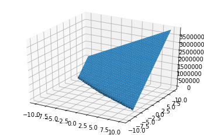

```python
b1 = np.linspace(-10, 10, 200)
b2 = np.linspace(-10, 10, 200)
B1, B2 = np.meshgrid(b1, b2)
Zbeta = np.array([log_likelihood(thing) for thing in zip(B1.ravel(), B2.ravel())])
Zbeta = Zbeta.reshape(B1.shape)
fig = plt.figure()
ax = fig.add_subplot(111, projection='3d')
ax.plot_surface(B1, B2, Zbeta)
plt.show()
```

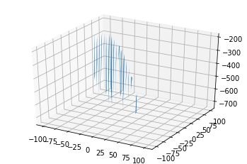

```python
b1 = np.linspace(-100, 100, 200)
b2 = np.linspace(-100, 100, 200)
B1, B2 = np.meshgrid(b1, b2)
Zbeta = np.array([np.log(likelihood(thing)) for thing in zip(B1.ravel(), B2.ravel())])
Zbeta = Zbeta.reshape(B1.shape)
fig = plt.figure()
ax = fig.add_subplot(111, projection='3d')
ax.plot_surface(B1, B2, Zbeta)
plt.show()
```

#### Multivariate Metropolis for Mixture of Gaussians

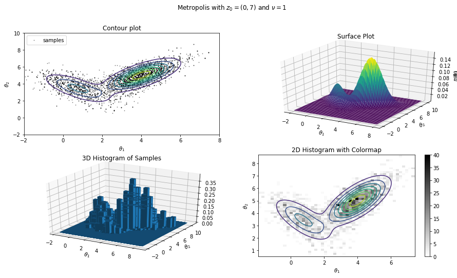

```python
from scipy.stats import multivariate_normal
import seaborn as sns

# target distribution
def mixture_gaussians(theta):
    # mean and covariance matrix for first term
    m1 = np.array([4, 5])
    v1 = np.array([[1.0, 0.7], [0.7, 1.0]])
    # mean and covariance matrix for second term
    m2 = np.array([0.7, 3.5])
    v2 = np.array([[1.0, -0.7],[-0.7, 1.0]])
    term1 = 0.7*multivariate_normal.pdf(theta, mean=m1, cov=v1)
    term2 = 0.3*multivariate_normal.pdf(theta, mean=m2, cov=v2)
    return term1 + term2


def Metropolis_multivariate(p, z0=None, n_samples=100, burn_in=0, thinning=1, v=1):
    z = z0 if z0 is not None else np.random.uniform(size=(2,))
    pz = p(z)
    # calculate total number of calculations
    tot = burn_in + (n_samples - 1) * thinning + 1
    # stores all the samples
    sample_list = np.zeros((tot, 2))
    # Generate uniform random numbers outside the loop
    u = np.random.uniform(size=tot)
    cov = v*np.eye(2)
    normal_shift = multivariate_normal.rvs(mean=np.zeros(2), cov=cov, size=tot)

    for i in range(tot):
        # Sample a candidate from Normal(mu, sigma)
        cand = z + normal_shift[i]
        # Acceptance probability
        try:
            p_cand = p(cand)
            prob = min(1, p_cand / pz)
        except (OverflowError, ValueError):
            continue

        if prob > u[i]:  # accept
            z = cand
            pz = p_cand  # to save computations

        sample_list[i, :] = z

    # Finally want to take every Mth sample in order to achieve independence
    return sample_list[burn_in::thinning]


def mcmc_plot(p, xrange, yrange, nsamples=5000, burn_in=0, thinning=1, v=1, z0=(4, 5)):
    """
    Creates a figure with 4 plots:
        1) Contour plot of target distribution with scattered samples
        2) 3D plot of the taget distribution
        3) 3D histogram of samples
        4) 2D histogram of samples with colormap
    Returns
    -------

    """
    # Prepare data for 3D histogram (?)
    X, Y = np.meshgrid(xrange, yrange)
    zs = np.array(
        [mixture_gaussians(thing) for thing in zip(np.ravel(X), np.ravel(Y))]
    )
    Z = zs.reshape(X.shape)
    # with v=100 jump is too large, few accepted. v=0.01 doesnt explore
    samples = Metropolis_multivariate(
        p=p,
        z0=z0,
        n_samples=nsamples,
        burn_in=burn_in,
        thinning=thinning,
        v=v
    )
    # Do stuff
    # Plot the results
    fig = plt.figure(figsize=(15, 8))
    fig.suptitle(r'Metropolis with $z_0={}$ and $\nu={}$'.format(z0, v))
    # Contour
    ax1 = fig.add_subplot(2, 2, 1)
    ax1.contour(X, Y, Z)
    ax1.scatter(*samples.T, s=0.5, c='k', alpha=0.5, label='samples')
    ax1.set_xlabel(r'$\theta_1$')
    ax1.set_ylabel(r'$\theta_2$')
    ax1.set_title("Contour plot")
    ax1.legend()
    # Surface plot
    ax2 = fig.add_subplot(2, 2, 2, projection='3d')
    ax2.plot_surface(X, Y, Z, cmap='viridis')
    ax2.set_xlabel(r'$\theta_1$')
    ax2.set_ylabel(r'$\theta_2$')
    ax2.set_zlabel(r'$\pi(\bf{\theta})$')
    ax2.set_title("Surface Plot")
    # 3D histogram plot
    ax3 = fig.add_subplot(2, 2, 3, projection='3d')
    x, y = samples[:, 0], samples[:, 1]
    hist, xedges, yedges = np.histogram2d(x, y, bins=100,
                                          range=[[-2, 8], [-2, 10]], density=True)
    xpos, ypos = np.meshgrid(xedges[:-1] + 0.25, yedges[:-1] + 0.25, indexing="ij")
    xpos = xpos.ravel()
    ypos = ypos.ravel()
    zpos = 0
    dx = dy = 0.5 * np.ones_like(zpos)
    dz = hist.ravel()
    ax3.bar3d(xpos, ypos, zpos, dx, dy, dz)
    ax3.set_title('3D Histogram of Samples')
    ax3.set_xlabel(r'$\theta_1$')
    ax3.set_ylabel(r'$\theta_2$')
    # 2D Histogram with Colormap
    ax4 = fig.add_subplot(2, 2, 4)
    ax4.set_title("2D Histogram with Colormap")
    ax4.set_xlabel(r'$\theta_1$')
    ax4.set_ylabel(r'$\theta_2$')
    _h, _x, _y, im = ax4.hist2d(samples[:, 0], samples[:, 1], bins=(50, 50), cmap=plt.cm.binary)
    ax4.contour(X, Y, Z)
    fig.colorbar(im, ax=ax4)
    plt.show()


xrange = np.linspace(-2, 8, 100)
yrange = np.linspace(-2, 10, 100)
mcmc_plot(mixture_gaussians, xrange, yrange, nsamples=5000, burn_in=0, thinning=1,v=1, z0=(0, 7))
```